# Assignment 5: Mixed models

Marton Kovacs / Zoltan Kekecs

# Introduction

This assignment is related to the previous lab assignment concerning perioperative pain and its psychological and hormonal predictors. Just like previously, you will set up linear model to predict postoperative pain after wisdom tooth surgery, but this time you will have to also take into account the fact that there is clustering in the data.

As a reminder, here is the protocol for data collection: “You have collected data from adults who were scheduled to undergo surgical extraction of the third mandibular molar (wisdom tooth surgery). Patients filled out a form in the waiting room before their surgery. The form contained questions about their sex, age, and weight, and psychological questionnaires assessing anxiety, pain catastrophizing, and mindfulness (see descriptions below). You also got blood samples and saliva samples from participants in the waiting room 5 minutes before their operations to determine the serum (a component of the blood) and salivary cortisol levels of participants. Participants were contacted 5 hours after the surgery to see how much pain they were experiencing. The **level of pain** at that moment was recorded using a numerical rating scale using a **scale of 0 to 10**, where 0 means “no pain” and 10 means “worst pain I can imagine”.

**The State Trait Anxiety Inventory:** T measures trait anxiety on a scale of 20 to 80, higher scores mean higher anxiety. Anxiety has been found in many studies to positively correlate with the level of pain experienced. This is **variable STAI_trait** in the dataset.

**The Pain Catastrophizing Scale** measures the extent of pain catastrophizing, which is characterized by a tendency to magnify the threat value of a pain stimulus and to feel helpless in the presence of pain, as well as by a relative inability to prevent or inhibit pain-related thoughts in anticipation of, during, or following a painful event. The total score on this scale ranges from 0 to 52, higher scores mean higher catastrophizing. Pain catastrophizing is one of the well-established predictors of clinical pain. This is **variable pain_cat** in the dataset.

**The Mindful Attention Awareness Scale (MAAS)** measures dispositional mindfulness, which may be described as a tendency to turn attention to present-moment experiences in an open, non-judgemental way. The MAAS total score ranges from 1 to 6 (an average of the item scores), with higher scores representing higher dispositional mindfulness. Trait mindfulness has been theorized to serve as a protective factor against pain, as the individual would be more objective about their pain experience and tend to associate less discomfort, despair, and hopelessness to the pain-related sensations. This is **variable mindfulness** in the dataset.

**Cortisol** is a stress hormone associated with acute and chronic stress. Cortisol levels are thought to be positively associated with pain experience. Cortisol can be **measured from both blood and the saliva**, although, serum cortisol is often regarded in medical research as more reliably related to stress (serum is a component of the blood plasma). These are **variables cortisol_serum**, and **cortisol_saliva** in the dataset.”

# Datasets

You will need two datasets for this assignment, datafile A and B. You can load them from the ‘data/’ folder.

# Task

First, fit a linear mixed model to estimate postoperative pain on datafile A. You should use the same fixed effect predictors as you used in your final model in the 3 assignment. (If you did not do that assignment, use the following predictors: age, sex, STAI, pain catastrophizing, mindfulness, and serum cortisol.) Importantly, the model has to account for the clustering of the data in different hospital sites. We have no reason to assume that the effects of the different predictors would be different in the different hospitals, so fit a random intercept model including the random intercept of hospital-ID. Once the model is built, note the model coefficients and the confidence intervals of the coefficients for all fixed effect predictors, and compare them to the ones obtained in the 3 assignment.

Also, compute the variance explained by the fixed effect predictors using marginal R<sup>2</sup>, and the variance explained by the fixed and random effect terms combined using conditional R<sup>2</sup>. Now use the model coefficients obtained on data file A to predict pain in datafile B.

**IMPORTANT:** Do not fit the regression models on data file B (don’t re-train your models), just use the regression equation you derived based on datafile A. These regression equations should be applied on the new data (datafile B), to predict pain.

Now compute the variance explained by the model on datafile B. You can do this by using the formula: **1 - (RSS / TSS) = R^2**. Compare this R<sup>2</sup> to the marginal and conditional R<sup>2</sup> values computed for the model on datafile A.

# What to report

Report the model coefficients and the confidence intervals of the coefficients for each fixed effect predictor obtained on data file A in a table.

Report the variance components for the fixed effects, the random intercept, and the residuals (from the model on data file A). Also report the marginal R<sup>2</sup> and the conditional R<sup>2</sup> squared obtained from the model on data file A, and the observed R<sup>2</sup> of this model for data file B.

# What to discuss

Compare the model coefficients and the confidence intervals observed in this assignment and the assignment for Lab 2 and discuss what you think the differences or similarities mean.

# Solution

## Read the data

Read the datasets used in this assignment. Pay attention to the extensions of the datafiles.

```r
if(!require("tidyverse")) install.packages("tidyverse")
if(!require("here")) install.packages("here")
```

```
## here() starts at C:/University/ELTE/PhD/Okulás/1st semester/Statisztikai programozás/elte-ppk-r-course-Fall-2025
```

```r
if(!require("haven")) install.packages("haven")
if(!require("patchwork")) install.packages("patchwork")
if(!require("lme4")) install.packages("lme4")
if(!require("lmerTest")) install.packages("lmerTest")
if(!require("performance")) install.packages("performance")
if(!require("see")) install.packages("see")
```

```r
if(!require("sjPlot")) install.packages("sjPlot")
if(!require("broom")) install.packages("broom")
if(!require("broom.mixed")) install.packages("broom.mixed")
if(!require("MuMIn")) install.packages("MuMIn")
library(sjPlot)
library(performance)
library(tidyverse)
library(here)
library(haven)
library(patchwork)
library(lme4)
library(lmerTest)
library(see)
library(broom)
library(broom.mixed)
library(MuMIn)

here::i_am("README.md")
```

```
## here() starts at C:/University/ELTE/PhD/Okulás/1st semester/Statisztikai programozás/elte-ppk-r-course-Fall-2025
```

```r
data_a <- read_sav(here("data", "assignment_4_dataset_A.sav"))
data_b <- read_sav(here("data", "assignment_4_dataset_B.sav"))
```

## Exploratory data analysis

Run an exploratory data analysis (EDA) to investigate the dataset.

```r
variables = c("pain", "age", "weight", "STAI_trait", "pain_cat", "mindfulness", "cortisol_serum", "cortisol_saliva", "IQ", "household_income")


# Distribution of each variable
distribution = function(variables){
  var = sym(variables)

  data_a |>
  ggplot(aes(x = !!var)) +
  geom_histogram() +
    #xlim(0, NA) +
    #ylim(0, NA) +
    theme_minimal()
}

for (i in variables){
  assign(paste0(i, "_distribution"), distribution(i))
}

# Plot all distributions together
all_distributions = age_distribution + weight_distribution + IQ_distribution + household_income_distribution + pain_distribution + pain_cat_distribution + STAI_trait_distribution + mindfulness_distribution + cortisol_serum_distribution + cortisol_saliva_distribution + plot_layout(ncol = 3, axis_titles = "collect_y")

# Save plot
ggsave(here("assignment_4_materials", "all_distributions.png"))
# Distributions seem fine
```

# Summary statistics of each variable

```r
summary_stats <- data.frame()

for (s in variables) {
  scores <- data_a[[s]]

  min_val <- min(scores, na.rm = TRUE)
  max_val <- max(scores, na.rm = TRUE)
  mean_val <- mean(scores, na.rm = TRUE)
  median_val = median(scores, na.rm = TRUE)
  sd_val <- sd(scores, na.rm = TRUE)
  se_val <- sd_val / sqrt(sum(!is.na(scores)))
  shapiro <- tryCatch({
    shapiro.test(scores)$p.value
  }, error = function(e) NA)
  normal = ifelse(shapiro < 0.05, FALSE, TRUE)


  summary_stats <- rbind(summary_stats, data.frame(
    variables = s,
    min = min_val,
    max = max_val,
    mean = mean_val,
    median = median_val,
    sd = sd_val,
    se = se_val,
    shapiro = shapiro,
    normal = normal
  ))
}

# Show summary statistics
View(summary_stats)
```

## Correct coding errors

If you find values in the dataset during the EDA, that are not correct based on the provided descriptions of the variables of the dataset please correct them here.

```r
# Coding error 1:
# ID, sex, and hospital are character vectors instead of factor

data_a_clean = data_a |>
  rename(stai = STAI_trait) |>
  mutate(ID = as.integer(str_remove(ID, "ID_")),
         hospital = as.factor(str_remove(hospital, "hospital_")),
         sex = as.factor(str_to_lower(sex)))

is.integer(data_a_clean$ID)
```

```
## [1] TRUE
```

```r
is.factor(data_a_clean$hospital)
```

```
## [1] TRUE
```

```r
levels(data_a_clean$sex)
```

```
## [1] "female" "male"
```

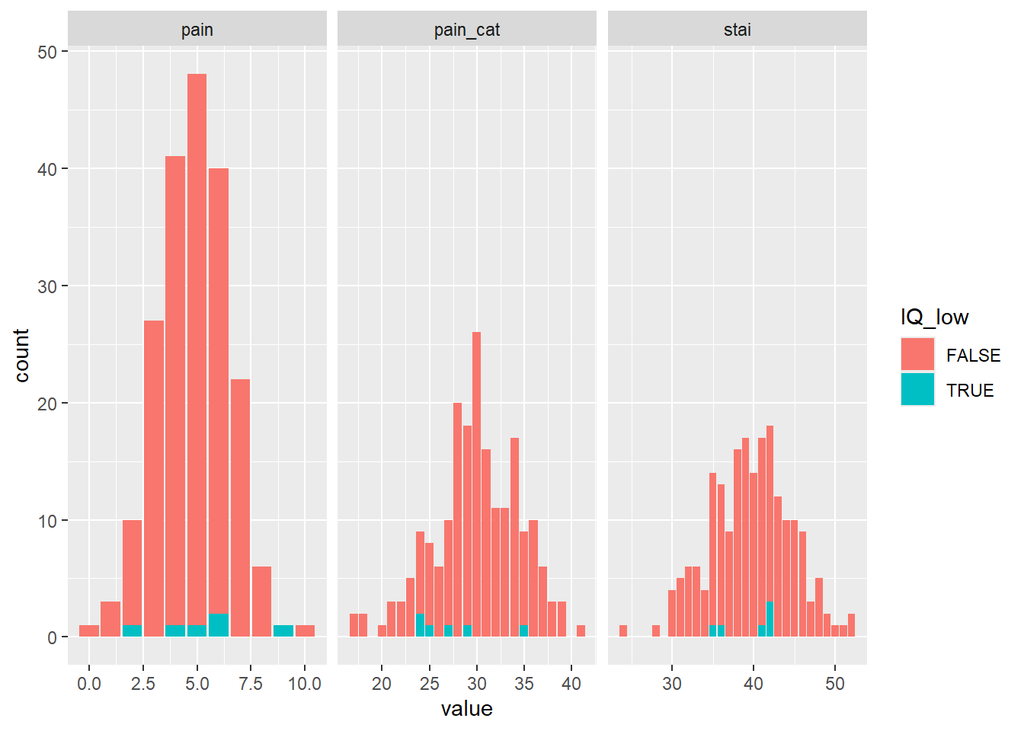

```r
# Coding error 2:
# Household income has negative values

data_a_clean = data_a_clean |>
  mutate(household_income = if_else(
    household_income < 0, NA_real_, household_income))

# Investigate if low IQ participant(s) understood STAI, pain_cat, and mindfulness questionnaires by comparing them to other respondents

data_a_clean |>
  mutate(IQ_low  = if_else(IQ < 70, TRUE, FALSE)) |>
  pivot_longer(cols = c(pain_cat, stai, pain), names_to = "variable", values_to = "value") |>
  ggplot(aes(x = value, fill = IQ_low)) +
  geom_bar() +
  facet_wrap(~ variable, scales = "free_x")
```

```r
# Participants with below 70 IQ do not show meaningful differences in interpretable questions, they stay for analysis
```

## Fit linear mixed effect model on Data A

```r
# Fit the model
model_a = lmer(pain ~ pain_cat + stai + mindfulness + cortisol_serum + age + sex + (1|hospital), data = data_a_clean)

# Summarize the model
summary(model_a)
```

```
## Linear mixed model fit by REML. t-tests use Satterthwaite's method [
## lmerModLmerTest]
## Formula: pain ~ pain_cat + stai + mindfulness + cortisol_serum + age +
##     sex + (1 | hospital)
##    Data: data_a_clean
##
## REML criterion at convergence: 682.6
##
## Scaled residuals:
##      Min       1Q   Median       3Q      Max
## -3.10080 -0.67358  0.05678  0.66353  2.78802
##
## Random effects:
##  Groups   Name        Variance Std.Dev.
##  hospital (Intercept) 0.3131   0.5596
##  Residual             1.4866   1.2193
## Number of obs: 200, groups:  hospital, 10
##
## Fixed effects:
##                  Estimate Std. Error         df t value Pr(>|t|)
## (Intercept)      3.502306   1.380454 192.019684   2.537  0.01197 *
## pain_cat         0.036885   0.028633 187.343455   1.288  0.19926
## stai             0.001437   0.023851 185.932388   0.060  0.95202
## mindfulness     -0.262441   0.100647 187.056391  -2.608  0.00986 **
## cortisol_serum   0.610010   0.114260 186.705239   5.339  2.7e-07 ***
## age             -0.054400   0.019818 189.297615  -2.745  0.00664 **
## sexmale          0.297545   0.190460 187.406434   1.562  0.11992
## ---
## Signif. codes:  0 '***' 0.001 '**' 0.01 '*' 0.05 '.' 0.1 ' ' 1
##
## Correlation of Fixed Effects:
##             (Intr) pan_ct stai   mndfln crtsl_ age
## pain_cat    -0.552
## stai        -0.104 -0.400
## mindfulness -0.569  0.483  0.032
## cortisl_srm -0.224 -0.078 -0.416  0.003
## age         -0.626  0.269 -0.321  0.056  0.261
## sexmale      0.144 -0.358  0.214 -0.076  0.001 -0.206
```

```r
r.squaredGLMM(model_a)
```

```
##            R2m       R2c
## [1,] 0.3167528 0.4356176
```

```r
coef(model_a)
```

```
## $hospital
##    (Intercept)   pain_cat     stai mindfulness cortisol_serum         age
## 1     3.551583 0.03688499 0.001437  -0.2624409        0.61001 -0.05439985
## 10    2.854724 0.03688499 0.001437  -0.2624409        0.61001 -0.05439985
## 2     2.973814 0.03688499 0.001437  -0.2624409        0.61001 -0.05439985
## 3     3.306241 0.03688499 0.001437  -0.2624409        0.61001 -0.05439985
## 4     4.098693 0.03688499 0.001437  -0.2624409        0.61001 -0.05439985
## 5     3.498027 0.03688499 0.001437  -0.2624409        0.61001 -0.05439985
## 6     2.891393 0.03688499 0.001437  -0.2624409        0.61001 -0.05439985
## 7     3.840262 0.03688499 0.001437  -0.2624409        0.61001 -0.05439985
## 8     3.707021 0.03688499 0.001437  -0.2624409        0.61001 -0.05439985
## 9     4.301300 0.03688499 0.001437  -0.2624409        0.61001 -0.05439985
##      sexmale
## 1  0.2975449
## 10 0.2975449
## 2  0.2975449
## 3  0.2975449
## 4  0.2975449
## 5  0.2975449
## 6  0.2975449
## 7  0.2975449
## 8  0.2975449
## 9  0.2975449
##
## attr(,"class")
## [1] "coef.mer"
```

```r
confint(model_a)
```

```
## Computing profile confidence intervals ...
```

```
##                      2.5 %      97.5 %
## .sig01          0.29275254  0.94853398
## .sigma          1.08880037  1.33177484
## (Intercept)     0.84153742  6.20305781
## pain_cat       -0.01885807  0.09219691
## stai           -0.04472838  0.04774798
## mindfulness    -0.45779593 -0.06764763
## cortisol_serum  0.38893037  0.83190118
## age            -0.09363796 -0.01620546
## sexmale        -0.06956659  0.67142442
```

[figure not shown]

```r
# Plot the model coefficients
model_coefficients = sjPlot::plot_model(model_a,
                   show.values = TRUE, value.size = 3, value.offset = 0.3, vline.color = "black")
ggsave(here("assignment_4_materials", "model_coefficients.png"))
# Checking assumptions
check_model(model_a, verbose = TRUE)
```

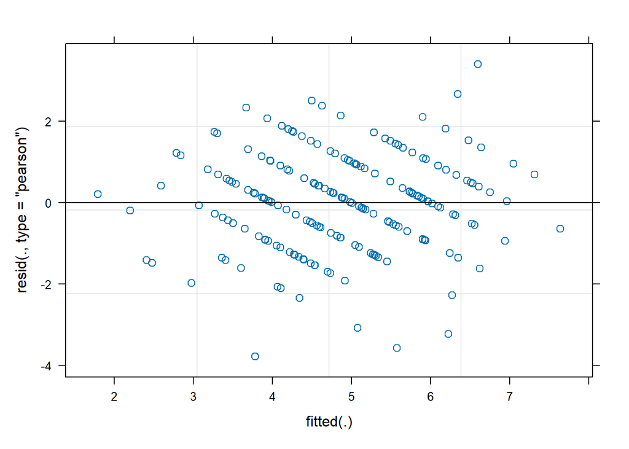

```r
### Seems that no assumptions have been violated, still, I will investigate the normality and homogeneity of variance assumptions further

## Constant variance

plot(model_a)
```

```r
check_heteroscedasticity(model_a)
```

```
## OK: Error variance appears to be homoscedastic (p = 0.887).
```